# Homework 1

## Train Models

```python
from interpret.glassbox import ExplainableBoostingClassifier
from sklearn.linear_model import LogisticRegression
from xgboost import XGBClassifier

random_state = 42
ebm_search = [{}, {'learning_rate': 0.1, 'learning_rate': 0.001}]
lr_search = [{}]
xgb_search = [{}]

ebm_best = None
lr_best = None
xgb_best = None

ebm_best_score = 0
lr_best_score = 0
xgb_best_score = 0

param_search = {'EBM': ebm_search, 'RF': lr_search, 'XGB': xgb_search}
models = {'EBM': ExplainableBoostingClassifier, 'RF': LogisticRegression, 'XGB': XGBClassifier}
best_ckpts = {'EBM': ebm_best, 'RF': lr_best, 'XGB': xgb_best}
best_scores = {'EBM': ebm_best_score, 'RF': lr_best_score, 'XGB': xgb_best_score}
```

```python
fn = lambda val: float(val)
```

```python
y_train.value_counts()
```

```
G3
10    118
11    117
13     88
12     82
14     77
15     71
8      58
9      48
16     44
0      39
17     32
18     19
7      14
6      14
5       6
19      6
1       1
20      1
dtype: int64
```

## Selecting best model

```python
for model_name in param_search.keys():
  print('Model name', model_name)
  for params in param_search[model_name]:
    model = models[model_name](random_state=random_state, **params)
    if model_name == 'EBM':
      model.fit(X_train, y_train)
    else:
      model.fit(X_train, y_train.apply(float, axis=1))
    score = model.score(X_test, y_test)
    if score > best_scores[model_name] or best_ckpts[model_name] is None:
        best_ckpts[model_name] = model
        best_scores[model_name] = score
```

```
WARNING:interpret.utils.all:Passing a numpy array to schema autogen when it should be dataframe.
WARNING:interpret.utils.all:Passing a numpy array to schema autogen when it should be dataframe.
```

```
Model name EBM
```

```
Multiclass is still experimental. Subject to change per release.
Detected multiclass problem: forcing interactions to 0
WARNING:interpret.utils.all:Passing a numpy array to schema autogen when it should be dataframe.
WARNING:interpret.utils.all:Passing a numpy array to schema autogen when it should be dataframe.
Multiclass is still experimental. Subject to change per release.
Detected multiclass problem: forcing interactions to 0
```

```
Model name RF
```

[output not shown]

```
Model name XGB
```

```python
results = pd.DataFrame({'Model': ['EBM', 'RF', 'XGB'], 'Score': [best_scores['EBM'], best_scores['RF'], best_scores['XGB']]})
results
```

|  | Model | Score |
| --- | --- | --- |
| 0 | EBM | 0.244019 |
| 1 | RF | 0.239234 |
| 2 | XGB | 0.186603 |

Final results looks like follow.

EBM reference: https://interpret.ml/docs/ebm.html

# Homework 2

For the selected models, prepare a knitr/jupyter notebook based on the following points (you can use models created in Homework 1). Submit your results on GitHub to the directory Homeworks/HW2.

Train a tree-based ensemble model on the selected dataset; it can be one of random forest, GBM, CatBoost, XGBoost, LightGBM (various types) etc.

Select two observations from the dataset and calculate the model's prediction. Next, for the same observations, calculate the decomposition of predictions, so-called variable attributions, using SHAP from two packages of choice, e.g. for Python: dalex and shap, for R: DALEX and iml.

Find any two observations in the dataset, such that they have different variables of the highest importance, e.g. age and gender have the highest (absolute) attribution for observation A, but race and class are more important for observation B.

(If possible) Select one variable X and find two observations in the dataset such that for one observation, X has a positive attribution, and for the other observation, X has a negative attribution. (How) Do the results differ across the two packages selected in point (3)?

(Using one explanation package of choice) Train another model of any class: neural network, linear model, decision tree etc. and find an observation for which SHAP attributions are different between this model and the one trained in point (1).

Comment on the results obtained in points (4)-(7)

## A2 Select two observations from the dataset and calculate the model's prediction.

```python
import shap

chosen_indices = list(range(10))
model = best_ckpts['RF']
test_subset, label = X_test.iloc[chosen_indices], y_test.iloc[chosen_indices]
preds = model.predict_proba(test_subset)

preds
```

```
array([[3.55984982e-17, 7.53556609e-07, 1.98320086e-03, 4.78554686e-03,
        1.74389642e-03, 1.41808225e-01, 3.50221591e-02, 2.66045639e-01,
        1.22098280e-01, 2.17886806e-01, 1.67405602e-02, 6.42374591e-02,
        7.04529392e-02, 1.97225053e-02, 2.77193403e-02, 8.53048681e-03,
        8.64483982e-04, 3.57717457e-04],
       [6.20070456e-05, 5.63245281e-04, 3.93144141e-03, 1.60463312e-02,
        2.96199229e-03, 5.20546710e-02, 1.59939488e-02, 1.84530299e-01,
        2.63065101e-01, 1.04558577e-01, 2.34234036e-01, 7.04711840e-02,
        2.35309221e-02, 1.42277657e-02, 1.01535086e-02, 3.47802762e-03,
        3.55419499e-05, 1.01400295e-04],
       [8.66069182e-04, 1.41694934e-04, 3.98722117e-03, 2.86808849e-03,
        4.71091714e-02, 3.78978572e-01, 1.23669340e-01, 2.54760306e-01,
        1.03226140e-01, 5.27657899e-02, 5.35083850e-03, 5.91650788e-03,
        9.58147671e-03, 3.49213953e-03, 1.65227314e-03, 5.52891436e-03,
        6.23599307e-05, 4.30963131e-05],
       [8.55487706e-09, 6.94334345e-06, 1.07315444e-03, 3.07051391e-02,
        3.21699804e-03, 1.23277465e-02, 2.56630667e-02, 1.79549914e-01,
        1.94522020e-01, 3.34889455e-02, 2.81860785e-01, 5.25901505e-02,
        2.48142551e-02, 6.51724848e-02, 9.75987106e-03, 4.67975502e-02,
        3.45875838e-02, 3.86338315e-03],
       [1.29540316e-01, 6.55928943e-04, 1.15924098e-03, 5.12105047e-03,
        5.43535195e-03, 3.92129009e-02, 2.17216240e-02, 7.41853457e-02,
        1.79758077e-01, 9.11357982e-02, 2.06475946e-01, 5.23641109e-02,
        4.94313670e-02, 8.05965438e-02, 5.27313853e-02, 8.22218069e-03,
        1.15696158e-03, 1.09587115e-03],
       [1.65602033e-02, 5.57507985e-04, 3.31071820e-04, 1.00927891e-02,
        2.26598062e-03, 4.31149520e-02, 6.75867049e-02, 1.56760828e-01,
        1.03922245e-01, 1.24561775e-01, 2.23461740e-01, 8.18238953e-02,
        3.56401656e-02, 6.08203223e-02, 5.23166351e-02, 1.65440182e-02,
        2.27904119e-03, 1.36012492e-03],
       [3.52830974e-22, 6.69081153e-08, 3.11054751e-02, 2.42760525e-03,
        2.36405074e-01, 6.54710448e-01, 1.88713900e-02, 5.09118422e-02,
        2.56888381e-03, 1.31536803e-03, 1.12858528e-04, 1.77296176e-04,
        1.17230808e-04, 4.86718486e-04, 2.25407800e-05, 7.42385334e-04,
        1.10892004e-05, 1.37271740e-05],
       [1.40871410e-09, 1.77791636e-05, 2.12353788e-03, 7.69090773e-03,
        1.20312766e-03, 5.38887131e-02, 1.37654349e-02, 7.20030162e-02,
        6.50244203e-02, 1.11860744e-01, 1.58332135e-01, 9.95241172e-02,
        2.21785441e-01, 5.08233638e-02, 9.23019549e-02, 2.59687234e-02,
        1.61137823e-02, 7.57280041e-03],
       [2.30331886e-04, 1.03610428e-04, 1.01257369e-03, 1.25042443e-03,
        6.87780521e-04, 6.87733534e-03, 5.37155138e-03, 6.30809267e-02,
        1.45536086e-01, 8.79583675e-02, 1.69212097e-01, 2.38833341e-01,
        1.78947285e-01, 5.26418079e-02, 4.18335772e-02, 4.76296824e-03,
        1.01226725e-03, 6.47668446e-04],
       [7.60278330e-15, 1.95554706e-06, 3.45389420e-03, 2.61945375e-03,
        2.69804876e-03, 4.92327963e-02, 8.92293045e-02, 1.89473833e-01,
        5.02096886e-01, 6.15248650e-02, 2.51577355e-02, 3.69889581e-02,
        2.80566611e-02, 7.34673927e-03, 5.37871174e-04, 1.50454898e-03,
        3.62234272e-05, 4.02254379e-05]])
```

```python
label
```

|  | G3 |
| --- | --- |
| 803 | 12 |
| 777 | 11 |
| 961 | 9 |
| 7 | 6 |
| 834 | 16 |
| 870 | 14 |
| 18 | 5 |
| 16 | 14 |
| 736 | 13 |
| 719 | 11 |

# A3

```python
import dalex as dx
pf = lambda m, d: m.predict_proba(d)
explainer = dx.Explainer(model, X_train, y_train, model_type='classification')

for i in range(len(test_subset)):
    explainer.predict_parts(test_subset.iloc[i], type="shap", label=f'example {i}').plot()
```

[output not shown]

```
X does not have valid feature names, but LogisticRegression was fitted with feature names
```

[interactive chart not shown]

[figure not shown]

[figure not shown]

[figure not shown]

```
0
```

```
1
```

```
2
```

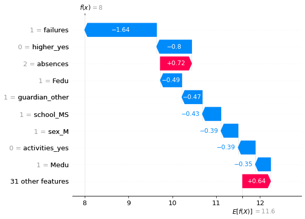

```
3
```

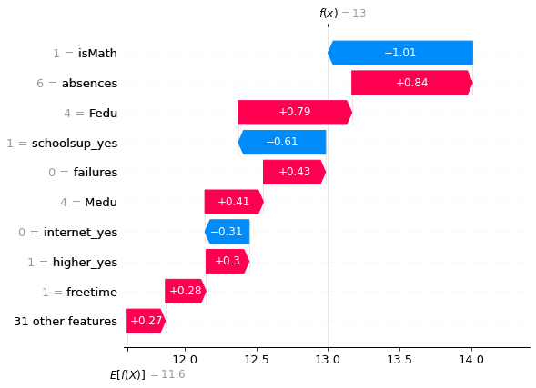

```
4
```

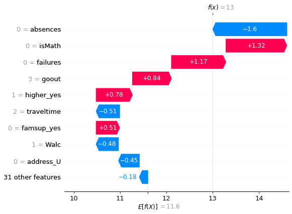

```
5
```

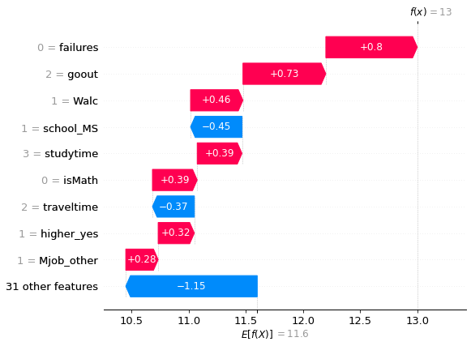

```
6
```

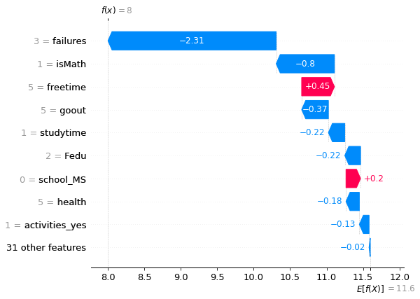

```
7
```

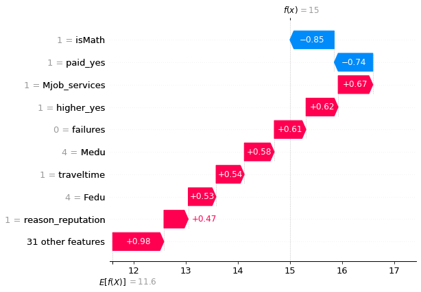

```
8
```

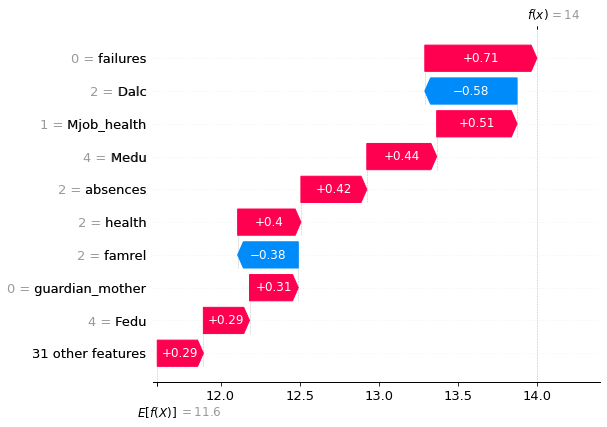

```
9
```

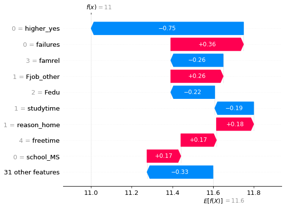

```python
shap_explainer = shap.Explainer(model.predict, test_subset)
shap_values = shap_explainer(test_subset)

for i, v in enumerate(shap_values):
    print(i)
    shap.plots.waterfall(v)
```

## A.4. Find any two observations in the dataset, such that they have different variables of the highest importance, e.g. age and gender have the highest (absolute) attribution for observation A, but race and class are more important for observation B.

```python
shap.plots.waterfall(shap_values[0])
```

[output not shown]

```python
shap.plots.waterfall(shap_values[1])
```

[output not shown]

## A.5. Select one variable X and find two observations in the dataset such that for one observation, X has a positive attribution, and for the other observation, X has a negative attribution.

[figure not shown]

## A.6 (How) Do the results differ across the two packages selected in point (3)?

I've run training many times and it seems that on half cases Dalex plots very nice explanations of contributions, while for others not. It can suggests that for this particular problem, explaining methods are nor very stable.

## A.7. (Using one explanation package of choice) Train another model of any class: neural network, linear model, decision tree etc. and find an observation for which SHAP attributions are different between this model and the one trained in point (1).

```
0
```

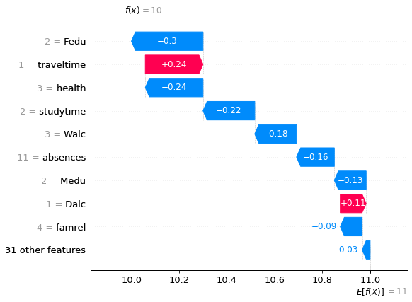

```
1
```

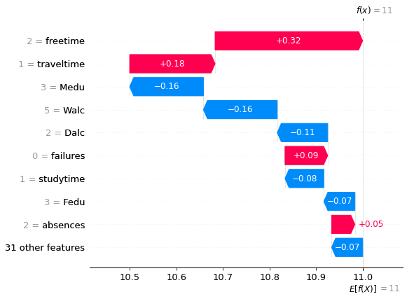

```
2
```

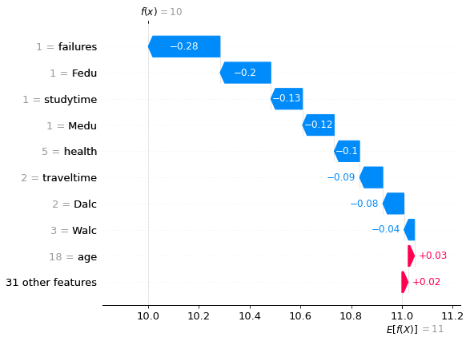

```
3
```

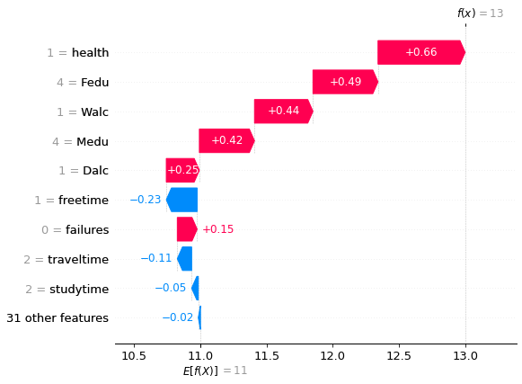

```
4
```

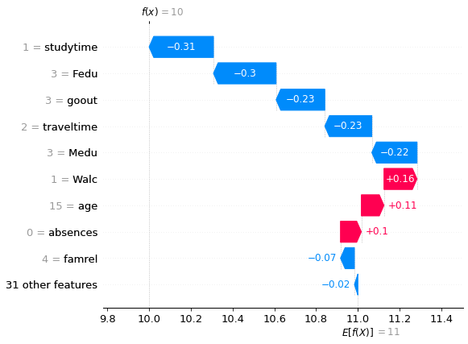

```
5
```

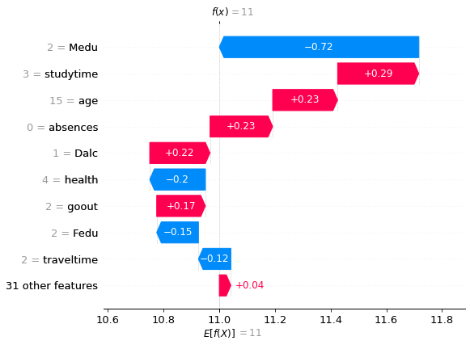

```
6
```

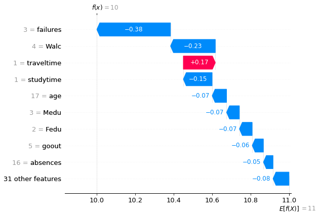

```
7
```

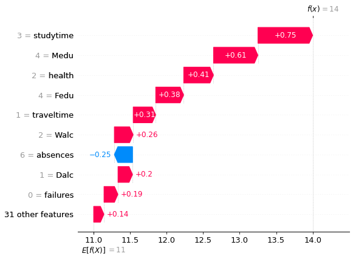

```
8
```

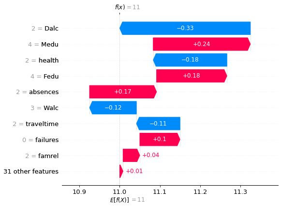

```
9
```

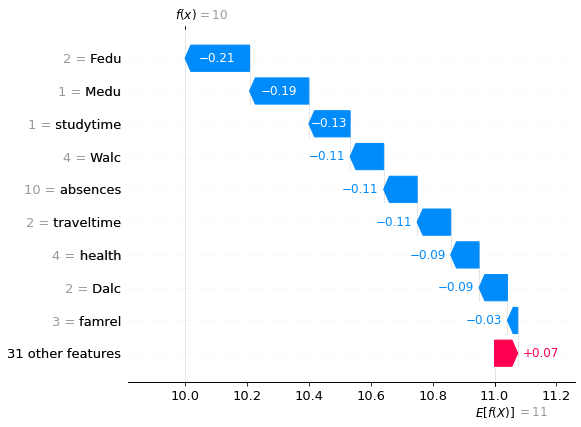

```python
model = best_ckpts['EBM']
shap_explainer = shap.Explainer(model.predict, test_subset)
shap_values = shap_explainer(test_subset)

for i, v in enumerate(shap_values):
    print(i)
    shap.plots.waterfall(v)
```

explainable boosting machines:

[figure not shown]

# Task B

Task B

V() = 0

V(A) - V() = 20

V(B, A) - V(B) = 40

V(C, A) - V(C) = 10

V(B, C, A) - V(B, C) = 30

Final answert: (2! *20 + 1!*40 + 1!*10+2!*30)/3! = 25

```python
!jupyter nbconvert --to=html mt406390_xai2.ipynb
```

```
[NbConvertApp] Converting notebook mt406390_xai2.ipynb to html
[NbConvertApp] Writing 2278625 bytes to mt406390_xai2.html
```